# Summarizing and Visualizing Sampling Frames, Design Sites, and Analysis Data

Michael Dumelle, Tom Kincaid, Anthony Olsen, and Marc Weber

If you have yet not read the “Start Here” vignette, please do so by running

```r
vignette("start-here", "spsurvey")
```

# 1 Introduction

Before proceeding, we load spsurvey by running

```r
library(spsurvey)
```

The `plot()` function in spsurvey is built on the `plot()` function in sf. spsurvey’s `plot()` function accommodates all the arguments in sf’s `plot()` function and adds a few additional features. To learn more about the `plot()` function in sf, run `?plot.sf()`.

# 2 Sampling frames

Summarizing and visualizing the sampling frame is often helpful to better understand your data and inform additional survey design options (e.g. stratification). To use `plot()` or `sp_summarize()`, sampling frames must either be an `sf` object or a data frame with x-coordinates, y-coordinates, and a crs (coordinate reference system).

The `NE_Lakes` data in spsurvey is a sampling frame (as an `sf` object) that contains lakes from the Northeastern United States. There are three variables in `NE_Lakes` you will use next:

1. `AREA_CAT`: lake area categories (small and large)
2. `ELEV`: lake elevation (a continuous variable)
3. `ELEV_CAT`: lake elevation categories (low and high)

Before summarizing or visualizing a sampling frame, turn it into an object using `sp_frame()`:

```r
NE_Lakes <- sp_frame(NE_Lakes)
```

## 2.1 One-sided formulas

One-sided formulas are used to summarize and visualize the distributions of variables. The variables of interest should be placed on the right-hand side of the formula. To summarize the distribution of `ELEV`, run

```r
summary(NE_Lakes, formula = ~ ELEV)
```

```
#>    total          ELEV
#>  total:195   Min.   :  0.00
#>              1st Qu.: 21.93
#>              Median : 69.09
#>              Mean   :127.39
#>              3rd Qu.:203.25
#>              Max.   :561.41
```

The output contains two columns: `total` and `ELEV`. The `total` column returns the total number of lakes, functioning as an “intercept” to the formula (it can by removed by supplying `- 1` to the formula). The `ELEV` column returns a numerical summary of lake elevation. To visualize `ELEV`, run

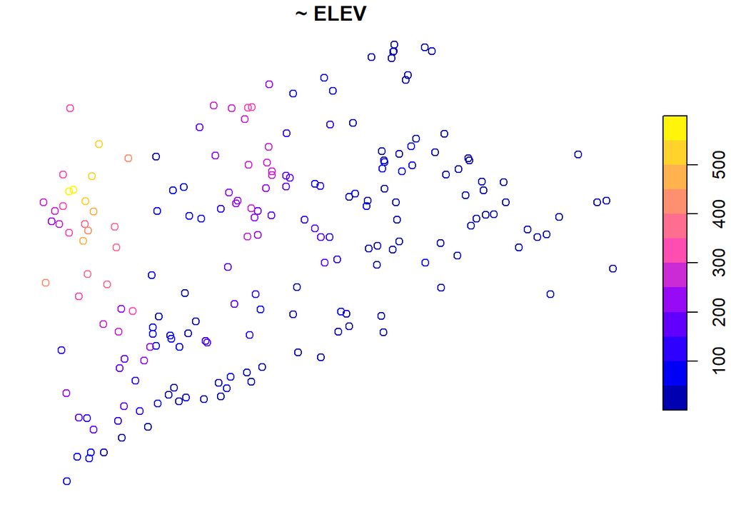

```r
plot(NE_Lakes, formula = ~ ELEV)
```

To summarize the distribution of `ELEV_CAT`, run

```r
summary(NE_Lakes, formula = ~ ELEV_CAT)
```

```
#>    total     ELEV_CAT
#>  total:195   low :112
#>              high: 83
```

The `ELEV_CAT` column returns the number of lakes in each elevation category. To visualize `ELEV_CAT`, run

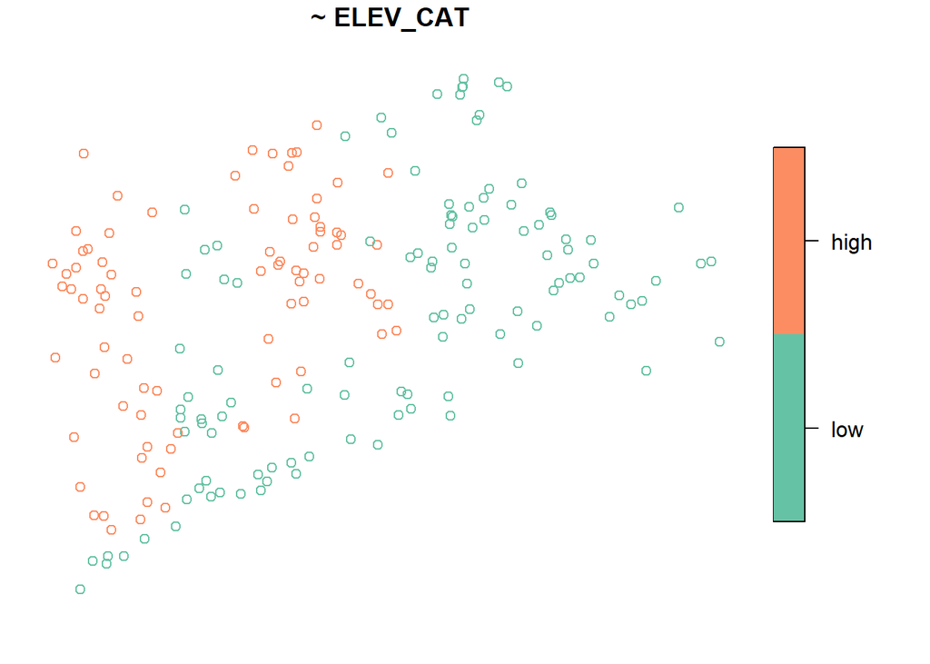

```r
plot(NE_Lakes, formula = ~ ELEV_CAT, key.width = lcm(3))
```

The `key.width` argument extends the plot’s margin to fit the legend text nicely within the plot. The plot’s default title is the `formula` argument, though this is changed using the `main` argument to `plot()`.

The formula used by `summary()` and `plot()` is quite flexible. Additional variables are included using `+`:

```r
summary(NE_Lakes, formula = ~ ELEV_CAT + AREA_CAT)
```

```
#>    total     ELEV_CAT    AREA_CAT
#>  total:195   low :112   small:135
#>              high: 83   large: 60
```

The `plot()` function returns two plots – one for `ELEV_CAT` and another for `AREA_CAT`:

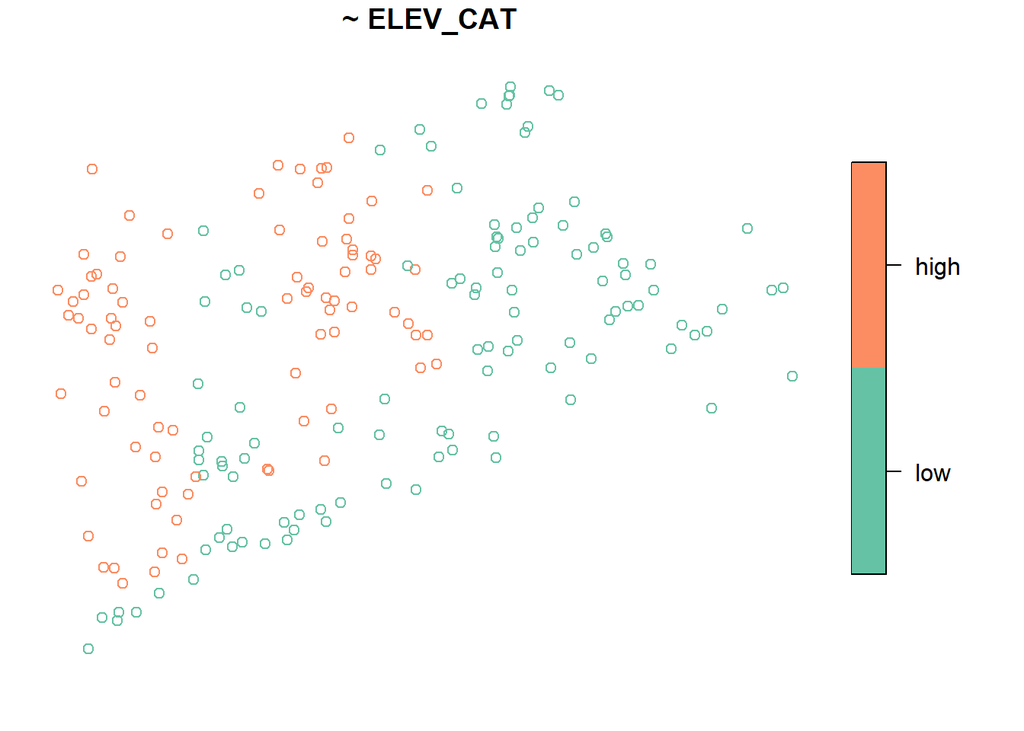

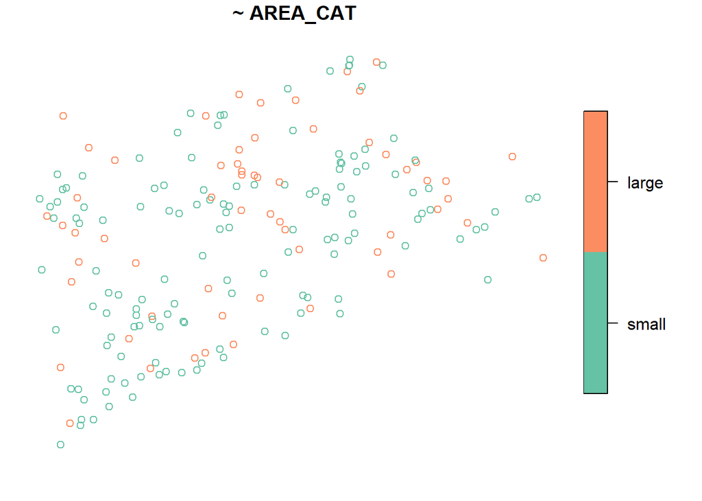

```r
plot(NE_Lakes, formula = ~ ELEV_CAT + AREA_CAT, key.width = lcm(3))
```

Interactions are included using the interaction operator, `:`. The interaction operator returns the interaction between variables and is most useful when used with categorical variables. To summarize the interaction between `ELEV_CAT` and `AREA_CAT`, run

```r
summary(NE_Lakes, formula = ~ ELEV_CAT:AREA_CAT)
```

```
#>    total      ELEV_CAT:AREA_CAT
#>  total:195   low:small :82
#>              high:small:53
#>              low:large :30
#>              high:large:30
```

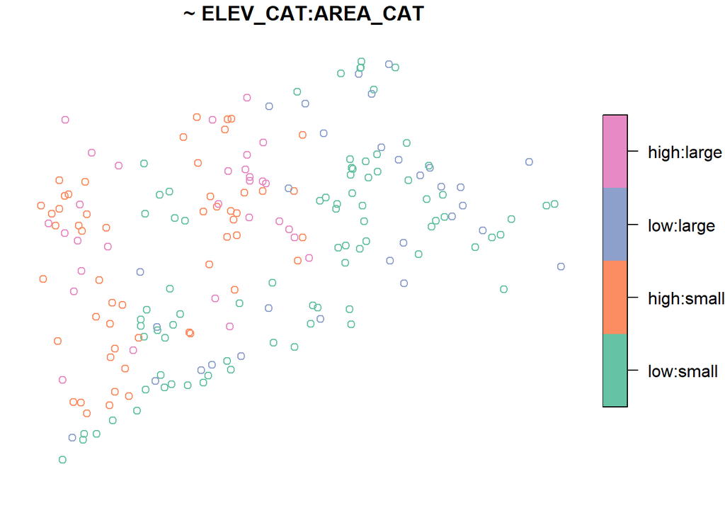

```r
plot(NE_Lakes, formula = ~ ELEV_CAT:AREA_CAT, key.width = lcm(3))
```

The formula accommodates the `*` operator, which combines the `+` and `:` operators. For example, `ELEV_CAT*AREA_CAT` is shorthand for `ELEV_CAT + AREA_CAT + ELEV_CAT:AREA_CAT`. The formula also accommodates the `.` operator, which is shorthand for all variables separated by `+`.

## 2.2 Two-sided formulas

Two-sided formulas are used to summarize the distribution of a left-hand side variable for each level of each right-hand side variable. To summarize the distribution of `ELEV` for each level of `AREA_CAT`, run

```r
summary(NE_Lakes, formula = ELEV ~ AREA_CAT)
```

```
#> ELEV by total:
#>       Min. 1st Qu. Median     Mean 3rd Qu.   Max.
#> total    0  21.925  69.09 127.3862 203.255 561.41
#>
#> ELEV by AREA_CAT:
#>       Min. 1st Qu.  Median     Mean  3rd Qu.   Max.
#> small 0.00   19.64  59.660 117.4473 176.1700 561.41
#> large 0.01   26.75 102.415 149.7487 241.2025 537.84
```

To visualize the distribution of `ELEV` for each level of `AREA_CAT`, run

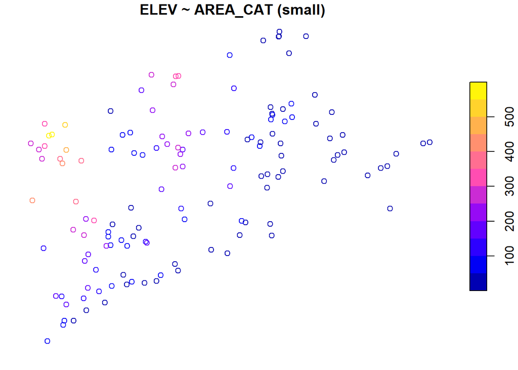

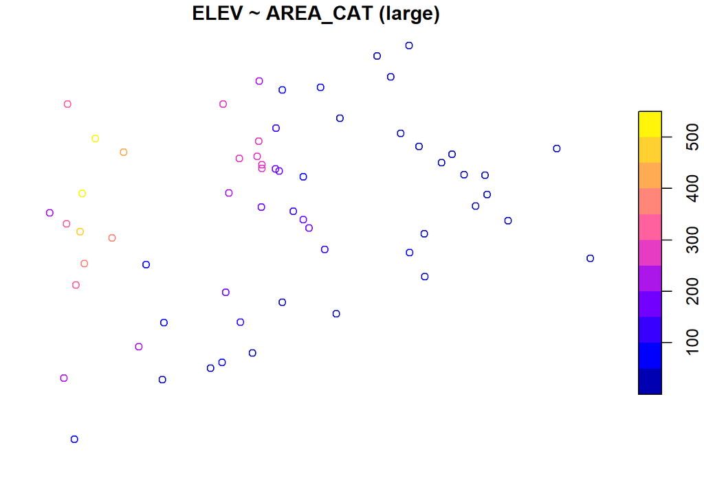

```r
plot(NE_Lakes, formula = ELEV ~ AREA_CAT)
```

To only summarize or visualize a particular level of a single right-hand side variable, use the `onlyshow` argument:

```r
summary(NE_Lakes, formula = ELEV ~ AREA_CAT, onlyshow = "small")
```

```
#> ELEV by AREA_CAT:
#>       Min. 1st Qu. Median     Mean 3rd Qu.   Max.
#> small    0   19.64  59.66 117.4473  176.17 561.41
```

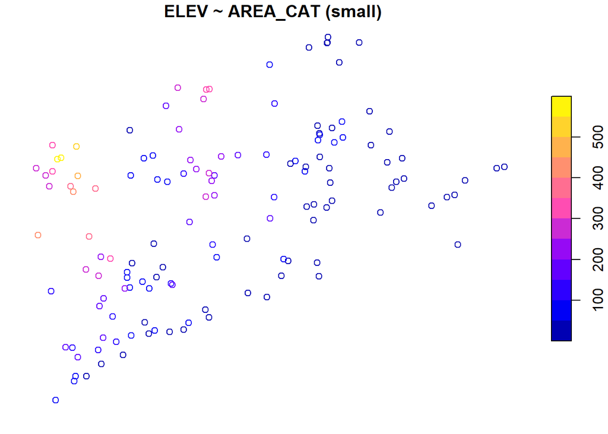

```r
plot(NE_Lakes, formula = ELEV ~ AREA_CAT, onlyshow = "small")
```

To summarize the distribution of `ELEV_CAT` for each level of `AREA_CAT`, run

```r
summary(NE_Lakes, formula = ELEV_CAT ~ AREA_CAT)
```

```
#> ELEV_CAT by total:
#>       low high
#> total 112   83
#>
#> ELEV_CAT by AREA_CAT:
#>       low high
#> small  82   53
#> large  30   30
```

To visualize the distribution of `ELEV_CAT` for each level of `AREA_CAT`, run

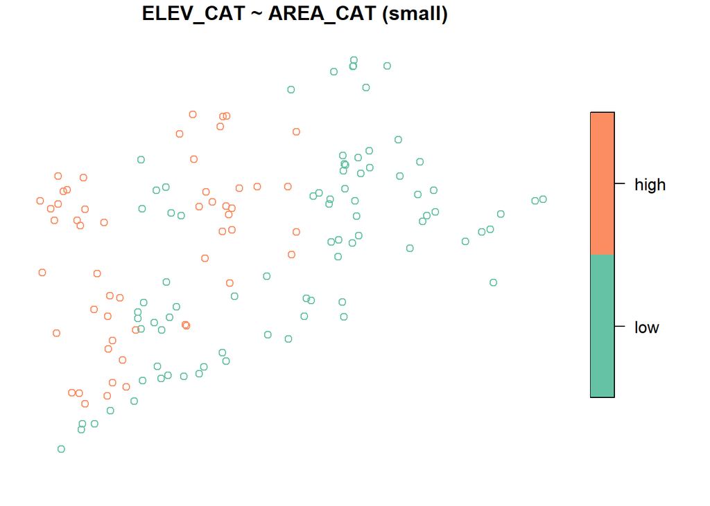

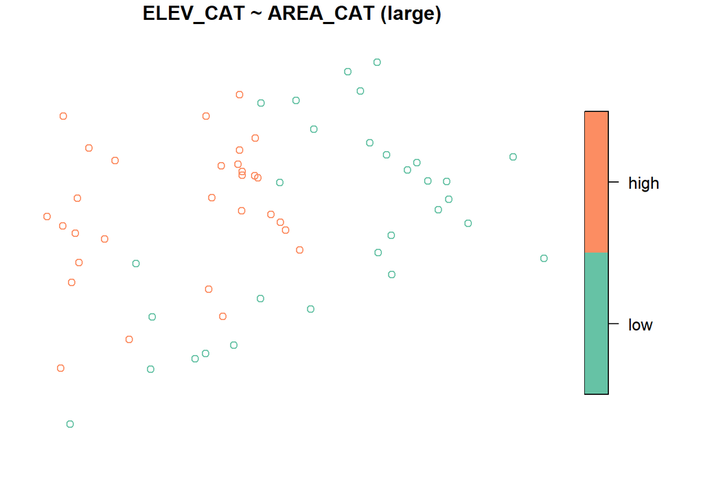

```r
plot(NE_Lakes, formula = ELEV_CAT ~ AREA_CAT, key.width = lcm(3))
```

## 2.3 Adjusting graphical parameters

There are three arguments in `plot()` that can adjust graphical parameters:

1. `var_args` adjusts graphical parameters simultaneously for all levels of a variable
2. `varlevel_args` adjusts graphical parameters uniquely for each level of a variable
3. `...` adjusts graphical parameters for simultaneously for all levels of all variables

The `var_args` and `varlevel_args` arguments take lists whose names match variable names in the formula. For `varlevel_args`, each list element must have an element named `levels` that matches the variable’s levels. The following example combines all three graphical parameter adjustment arguments:

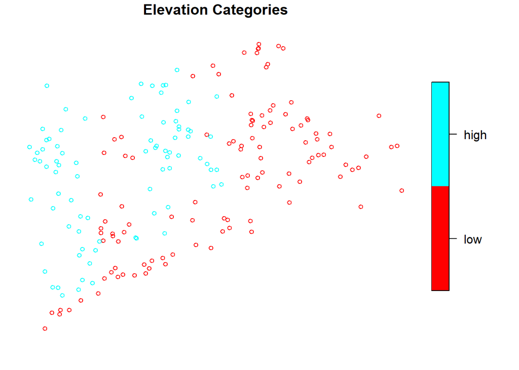

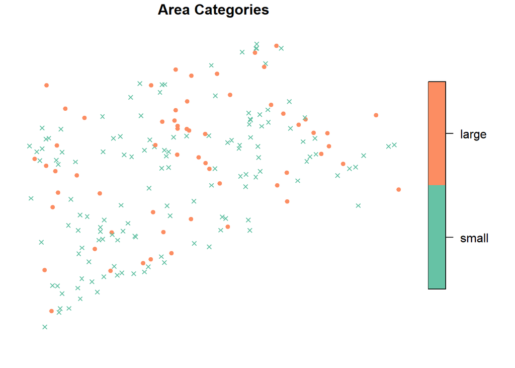

```r
list1 <- list(main = "Elevation Categories", pal = rainbow)
list2 <- list(main = "Area Categories")
list3 <- list(levels = c("small", "large"), pch = c(4, 19))
plot(
  NE_Lakes,
  formula = ~ ELEV_CAT + AREA_CAT,
  var_args = list(ELEV_CAT = list1, AREA_CAT = list2),
  varlevel_args = list(AREA_CAT = list3),
  cex = 0.75,
  key.width = lcm(3)
)
```

`var_args` uses `list1` to give the `ELEV_CAT` visualization a new title and color palette; `var_args` uses `list2` to give the `AREA_CAT` visualization a new title; `varlevel_args` uses `list3` to give the `AREA_CAT` visualization different shapes for the small and large levels; `...` uses `cex = 0.75` to reduce the size of all points; and `...` uses `key.width` to adjust legend spacing for all visualizations.

If a two-sided formula is used, it is possible to adjust graphical parameters of the left-hand side variable for all levels of a right-hand side variable. This occurs when a sublist matching the structure of `varlevel_args` is used as an argument to `var_args`. In this next example, different shapes are used for the small and large levels of `AREA_CAT` for all levels of `ELEV_CAT`:

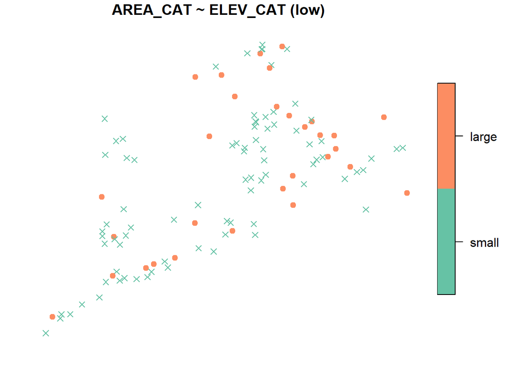

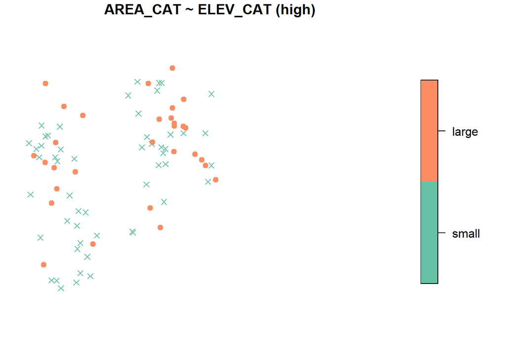

```r
sublist <- list(AREA_CAT = list3)
plot(
  NE_Lakes,
  formula = AREA_CAT ~ ELEV_CAT,
  var_args = list(ELEV_CAT = sublist),
  key.width = lcm(3)
)
```

# 3 Design sites

Design sites (output from the `grts()` or `irs()` functions) can be summarized and visualized using `summary()` and `plot()` very similarly to how sampling frames were summarized and visualized in the previous section. Soon you will use the `grts()` function to select a spatially balanced sample. The `grts()` function does incorporate randomness, so to match your results with this output exactly you will need to set a reproducible seed by running

```r
set.seed(51)
```

First we will obtain some design sites: To select an equal probability GRTS sample of size 50 with 10 reverse hierarchically ordered replacement sites, run

```r
eqprob_rho <- grts(NE_Lakes, n_base = 50, n_over = 10)
```

Similar to `summary()` and `plot()` for sampling frames, `summary()` and `plot()` for design sites uses a formula. The formula should include `siteuse`, which is the name of the variable in the design sites object that indicates the type of each site. The default formula for `summary()` and `plot()` is `~siteuse`, which summarizes or visualizes the `sites` objects in the design sites object. By default, the formula is applied to all non-`NULL` `sites` objects (in `eqprob_rho`, the non`NULL` sites objects are `sites_base` (for the base sites) and `sites_over` (for the reverse hierarchically ordered replacement sites)).

```r
summary(eqprob_rho)
```

```
#>    total    siteuse
#>  total:60   Base:50
#>             Over:10
```

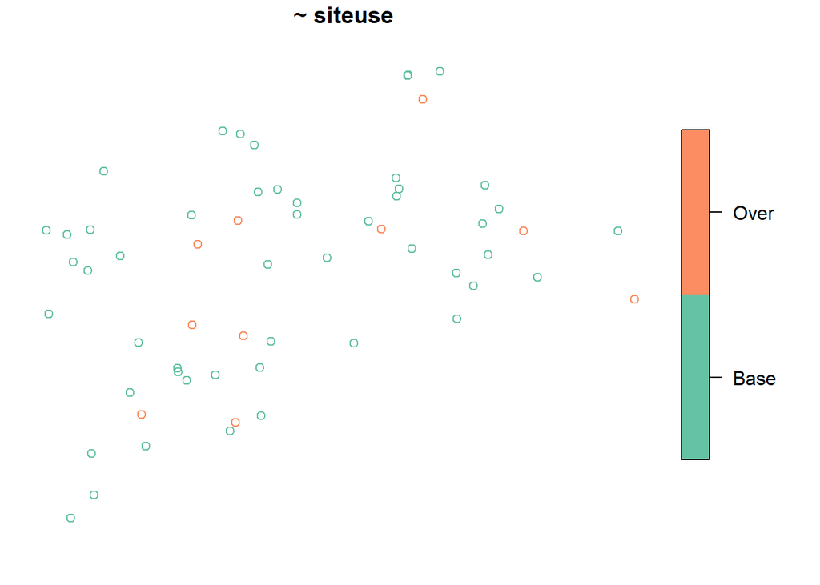

```r
plot(eqprob_rho, key.width = lcm(3))
```

The sampling frame may be included as an argument to the `plot()` function:

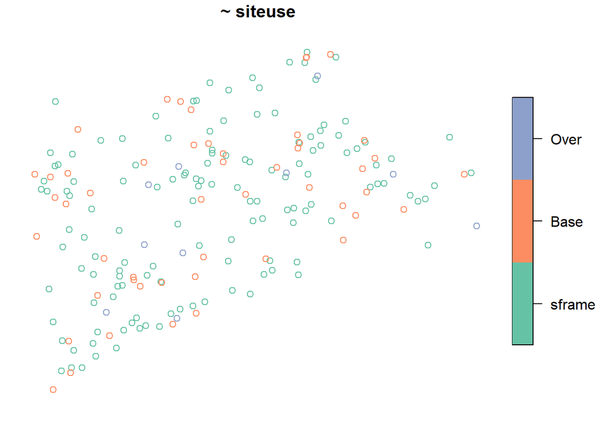

```r
plot(eqprob_rho, NE_Lakes, key.width = lcm(3))
```

When you include `siteuse` as a left-hand side variable (`siteuse` is treated as a categorical variable), you can summarize and visualize the `sites` object for each level of each right-hand side variable:

```r
summary(eqprob_rho, formula = siteuse ~ AREA_CAT)
```

```
#> siteuse by total:
#>       Base Over
#> total   50   10
#>
#> siteuse by AREA_CAT:
#>       Base Over
#> small   35    7
#> large   15    3
```

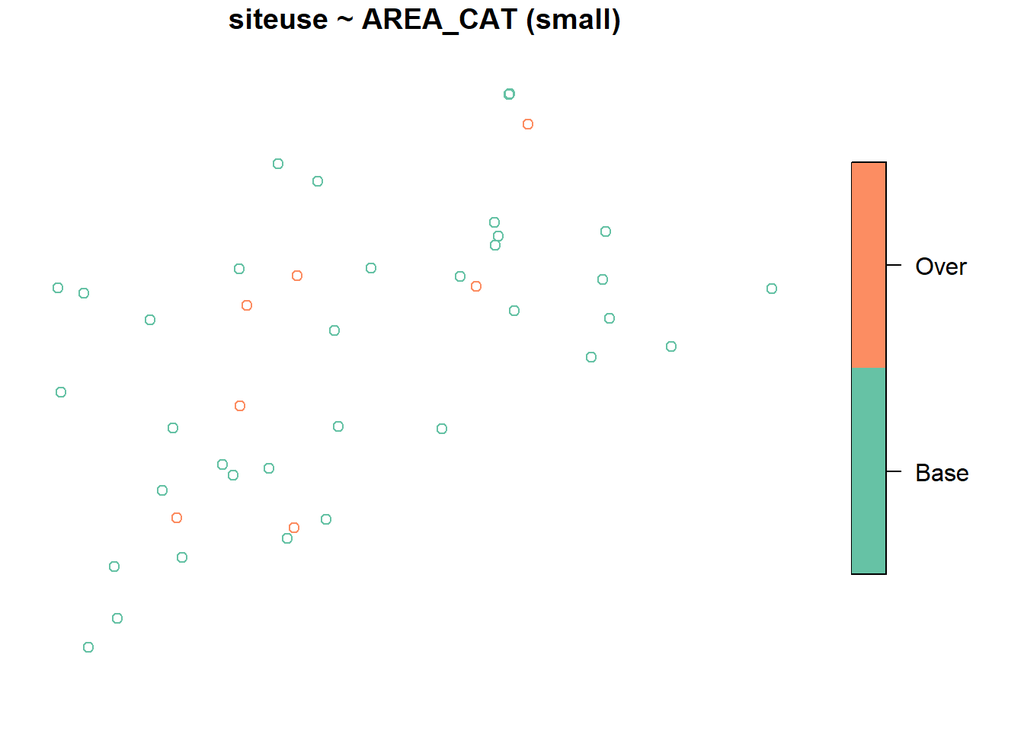

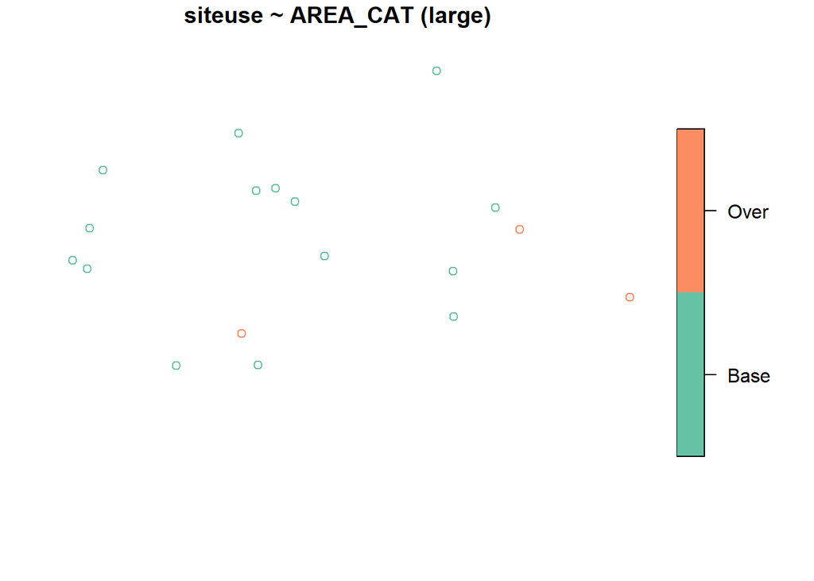

```r
plot(eqprob_rho, formula = siteuse ~ AREA_CAT, key.width = lcm(3))
```

You can also summarize and visualize a left-hand side variable for each level of `siteuse`:

```r
summary(eqprob_rho, formula = ELEV ~ siteuse)
```

```
#> ELEV by total:
#>       Min. 1st Qu. Median    Mean  3rd Qu.   Max.
#> total 0.03  26.385 65.535 135.364 214.2075 537.84
#>
#> ELEV by siteuse:
#>      Min. 1st Qu. Median     Mean 3rd Qu.   Max.
#> Base 0.68 29.4850  81.76 148.0362 263.640 537.84
#> Over 0.03 15.1275  54.49  72.0030 119.365 209.25
```

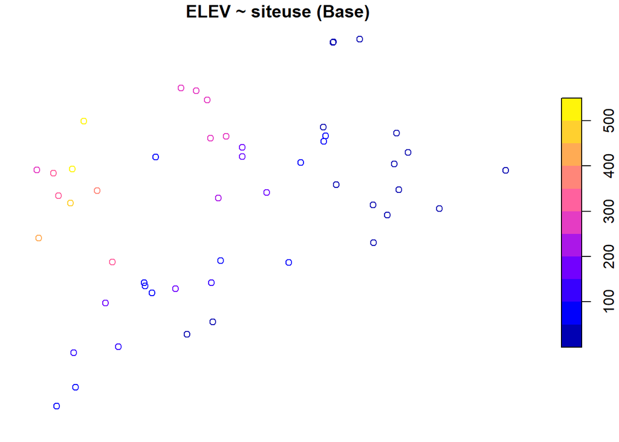

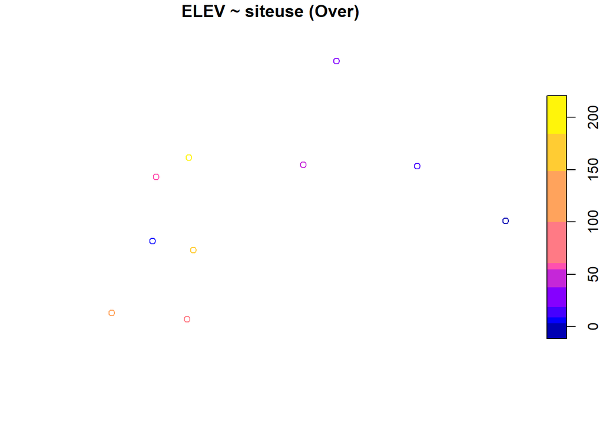

```r
plot(eqprob_rho, formula = ELEV ~ siteuse)
```

# 4 Analysis data

`sp_summarize()` and `plot()` work for analysis data the same way they do for sampling frames. The `NLA_PNW` analysis data in spsurvey is analysis data (as an `sf` object) from lakes in California, Oregon, and Washington. There are two variables in `NLA_PNW` you will use next:

1. `STATE`: state name (`California`, `Washington`, and `Oregon`)
2. `NITR_COND` : nitrogen content categories (`Poor`, `Fair`, and `Good`)

Before summarizing or visualizing a sampling frame, turn it into an object using `sp_frame()`:

```r
NLA_PNW <- sp_frame(NLA_PNW)
```

To summarize and visualize `NITR_COND` across all states, run

```r
summary(NLA_PNW, formula = ~ NITR_COND)
```

```
#>    total    NITR_COND
#>  total:96   Fair:24
#>             Good:38
#>             Poor:34
```

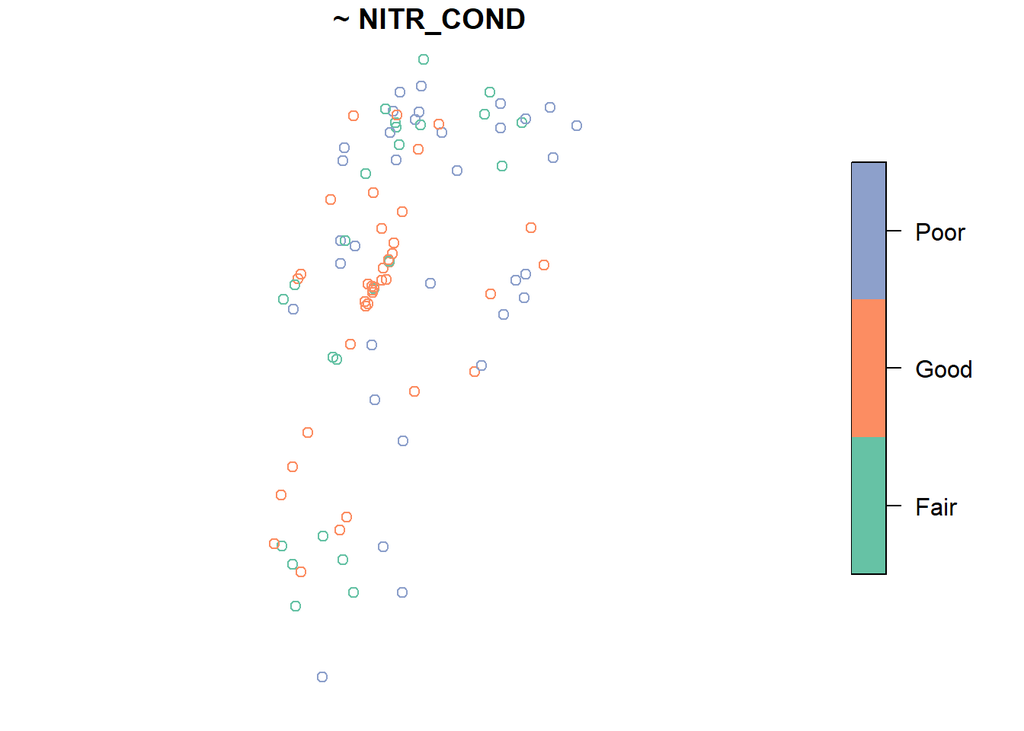

```r
plot(NLA_PNW, formula = ~ NITR_COND, key.width = lcm(3))
```

Suppose the sampling design was stratified by `STATE`. To summarize and visualize `NITR_COND` by `STATE`, run

```r
summary(NLA_PNW, formula = NITR_COND ~ STATE)
```

```
#> NITR_COND by total:
#>       Fair Good Poor
#> total   24   38   34
#>
#> NITR_COND by STATE:
#>            Fair Good Poor
#> California    6    8    5
#> Oregon        8   26   13
#> Washington   10    4   16
```

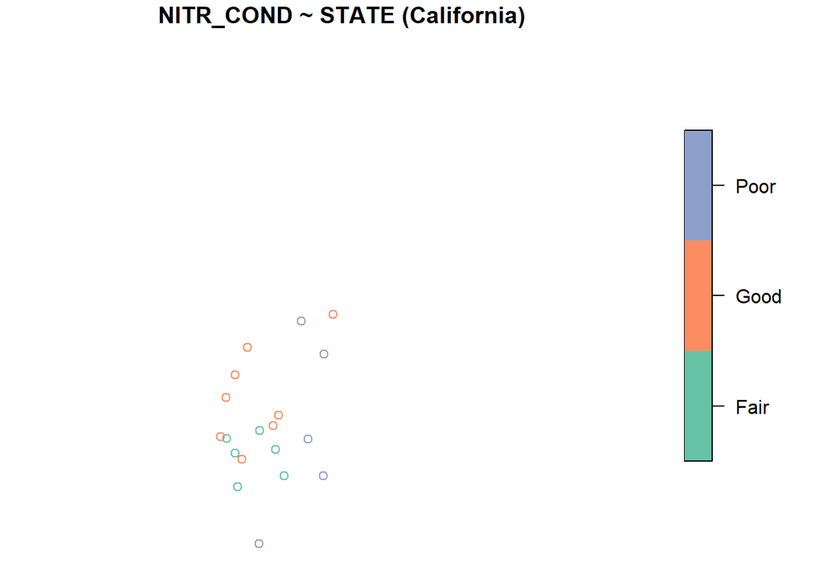

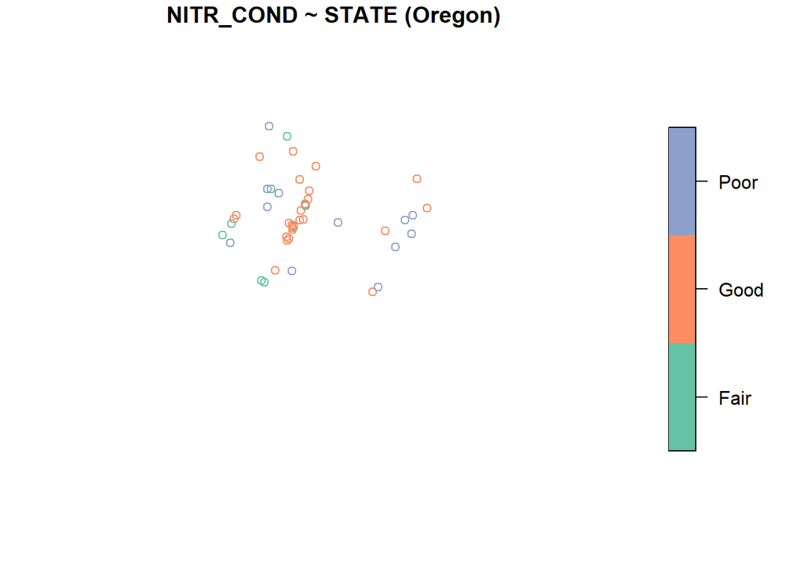

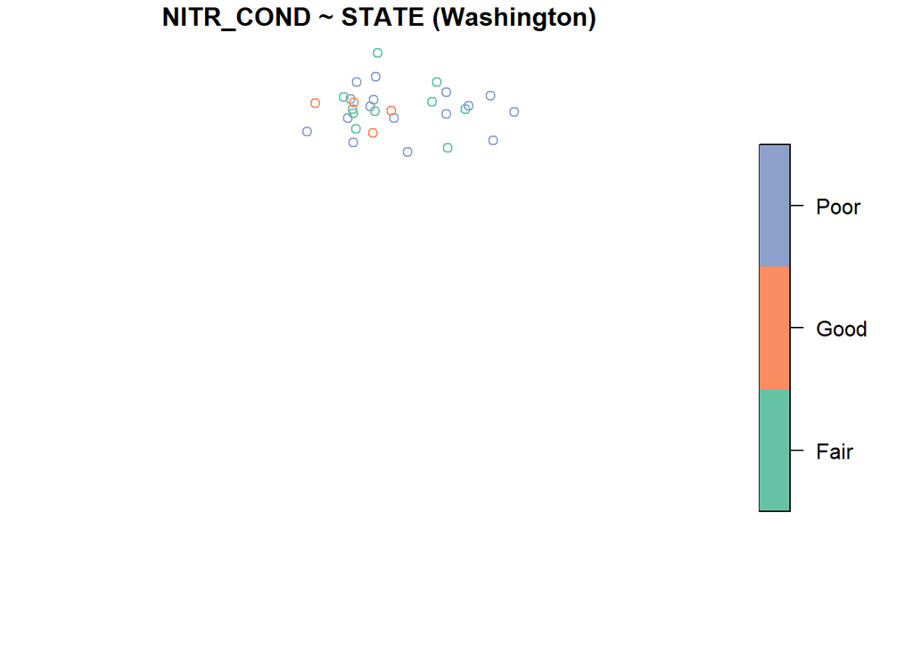

```r
plot(NLA_PNW, formula = NITR_COND ~ STATE, key.width = lcm(3))
```